# Structural Equation Models 2019

## Week 3

#### Exercise 3.1

The null hypothesis is that burnout is a multidimensional construct composed of three factors:

- Emotional Exhaustion (EE)
- Depersonalization (DP)
- Personal Accomplishment (PA)

Alternative hypothesis is that burnout is not a multidimensional construct composed of three factors.

Let us bring the data in R and prepare it for analysis:

Then let us do some EDA to see whether the items are normally distributed:

```
##        vars   n mean   sd median trimmed  mad min max range  skew kurtosis
## ITEM1     1 372 4.37 1.66    4.0    4.36 2.97   1   7     6 -0.11    -1.17
## ITEM2     2 372 4.87 1.55    5.0    4.97 1.48   1   7     6 -0.50    -0.71
## ITEM3     3 372 3.53 1.73    3.0    3.49 1.48   1   7     6  0.32    -1.11
## ITEM4     4 372 6.30 1.00    7.0    6.50 0.00   2   7     5 -1.80     3.63
## ITEM5     5 372 2.20 1.49    2.0    1.92 1.48   1   7     6  1.32     0.91
## ITEM6     6 372 2.71 1.58    2.0    2.50 1.48   1   7     6  0.92    -0.01
## ITEM7     7 372 6.31 0.84    6.0    6.46 1.48   2   7     5 -1.64     3.77
## ITEM8     8 372 3.04 1.73    2.0    2.89 1.48   1   7     6  0.74    -0.61
## ITEM9     9 372 6.03 1.32    7.0    6.29 0.00   1   7     6 -1.54     1.84
## ITEM10   10 372 2.20 1.45    2.0    1.96 1.48   1   7     6  1.20     0.56
## ITEM11   11 372 2.24 1.53    2.0    1.97 1.48   1   7     6  1.27     0.80
## ITEM12   12 372 5.70 1.19    6.0    5.86 1.48   1   7     6 -1.31     1.84
## ITEM13   13 372 3.59 1.68    3.5    3.52 2.22   1   7     6  0.35    -0.79
## ITEM14   14 372 4.03 1.73    4.0    4.01 1.48   1   7     6  0.03    -0.94
## ITEM15   15 372 1.77 1.30    1.0    1.47 0.00   1   7     6  2.09     4.24
## ITEM16   16 372 2.47 1.44    2.0    2.28 1.48   1   7     6  0.97     0.16
## ITEM17   17 372 6.41 0.85    7.0    6.58 0.00   2   7     5 -1.97     5.06
## ITEM18   18 372 5.70 1.27    6.0    5.87 1.48   1   7     6 -1.23     1.34
## ITEM19   19 372 5.95 1.19    6.0    6.15 1.48   1   7     6 -1.48     2.21
## ITEM20   20 372 2.24 1.41    2.0    2.01 1.48   1   7     6  1.29     1.17
## ITEM21   21 372 5.85 1.27    6.0    6.06 1.48   2   7     5 -1.29     1.16
## ITEM22   22 372 2.58 1.58    2.0    2.35 1.48   1   7     6  1.06     0.18
##          se
## ITEM1  0.09
## ITEM2  0.08
## ITEM3  0.09
## ITEM4  0.05
## ITEM5  0.08
## ITEM6  0.08
## ITEM7  0.04
## ITEM8  0.09
## ITEM9  0.07
## ITEM10 0.08
## ITEM11 0.08
## ITEM12 0.06
## ITEM13 0.09
## ITEM14 0.09
## ITEM15 0.07
## ITEM16 0.07
## ITEM17 0.04
## ITEM18 0.07
## ITEM19 0.06
## ITEM20 0.07
## ITEM21 0.07
## ITEM22 0.08
```

The skewness and kurtosis values for basicly all the items indicate that none of the items are normally distributed and therefore the maximum likelihood estimators are not suited for the task. Let us visualize the distributions of the items:

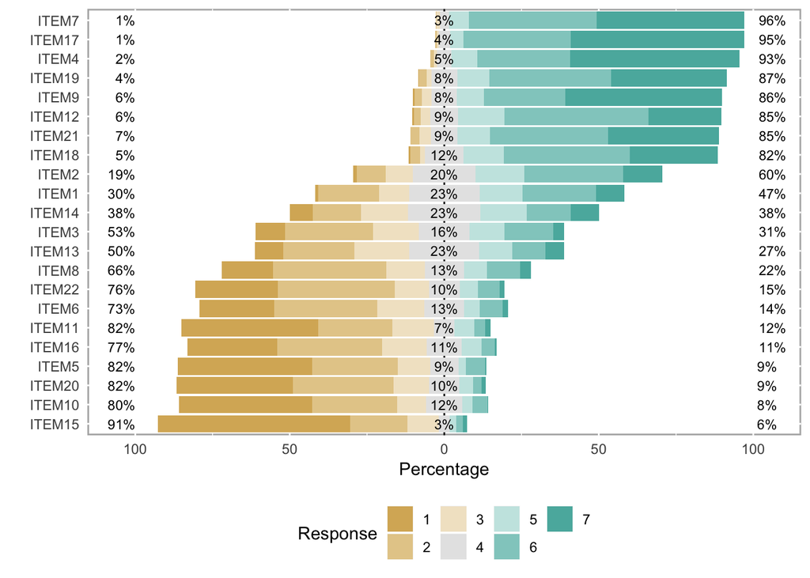

The visualization also shows that the items are not normally distributed.

#### ML estimator

Then let us specify the model according to instructions and visualize the model structure using ML estimator:

```
## lavaan 0.6-3 ended normally after 46 iterations
##
##   Optimization method                           NLMINB
##   Number of free parameters                         47
##
##   Number of observations                           372
##
##   Estimator                                         ML
##   Model Fit Test Statistic                     695.719
##   Degrees of freedom                               206
##   P-value (Chi-square)                           0.000
##
## Model test baseline model:
##
##   Minimum Function Test Statistic             3452.269
##   Degrees of freedom                               231
##   P-value                                        0.000
##
## User model versus baseline model:
##
##   Comparative Fit Index (CFI)                    0.848
##   Tucker-Lewis Index (TLI)                       0.830
##
## Loglikelihood and Information Criteria:
##
##   Loglikelihood user model (H0)             -12811.043
##   Loglikelihood unrestricted model (H1)     -12463.184
##
##   Number of free parameters                         47
##   Akaike (AIC)                               25716.087
##   Bayesian (BIC)                             25900.275
##   Sample-size adjusted Bayesian (BIC)        25751.158
##
## Root Mean Square Error of Approximation:
##
##   RMSEA                                          0.080
##   90 Percent Confidence Interval          0.073  0.087
##   P-value RMSEA <= 0.05                          0.000
##
## Standardized Root Mean Square Residual:
```

[output cut: 57 more lines]

```
##    .ITEM10            1.169    0.107   10.901    0.000
##    .ITEM11            1.044    0.112    9.330    0.000
##    .ITEM15            1.106    0.093   11.838    0.000
##    .ITEM22            2.076    0.160   12.958    0.000
##    .ITEM4             0.802    0.062   12.901    0.000
##    .ITEM7             0.523    0.042   12.572    0.000
##    .ITEM9             1.117    0.093   11.952    0.000
##    .ITEM12            0.987    0.080   12.287    0.000
##    .ITEM17            0.375    0.035   10.739    0.000
##    .ITEM18            0.909    0.081   11.224    0.000
##    .ITEM19            0.844    0.073   11.557    0.000
##    .ITEM21            1.245    0.098   12.764    0.000
##     EE                1.625    0.190    8.551    0.000
##     DP                0.705    0.132    5.321    0.000
##     PA                0.193    0.048    4.047    0.000
```

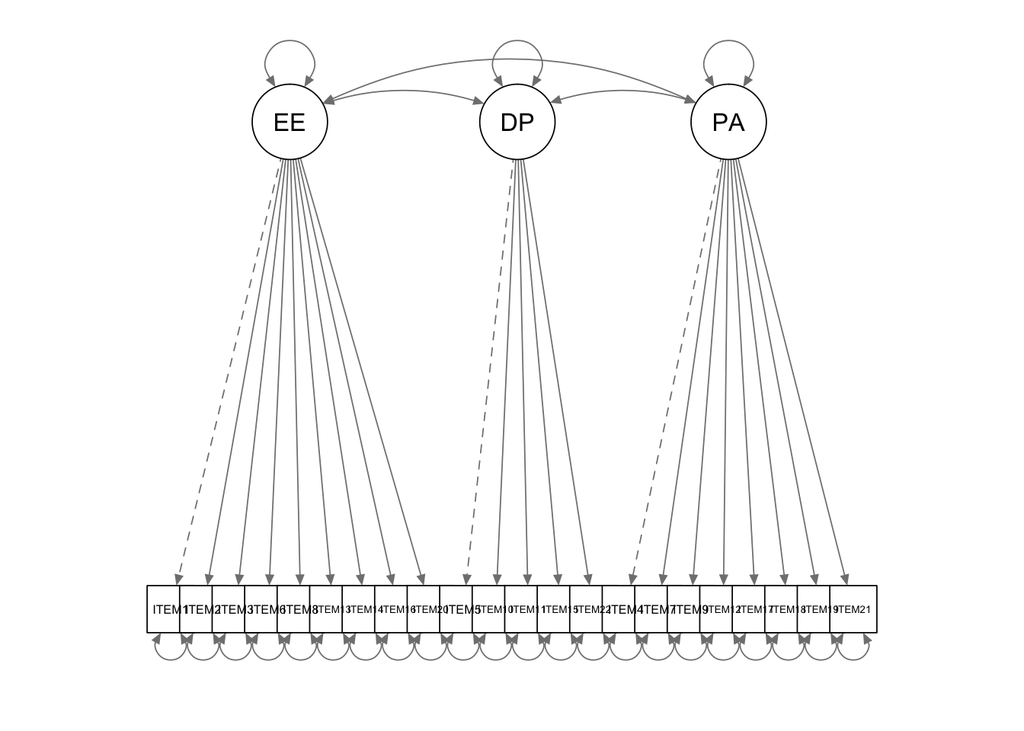

The hypothesis that burnout has three factors is not supported by the results (chi square statistic = 695.719, p = 0.000), which suggest that the fit of the data to the model is not adequate and null hypothesis should be rejected. Also the indices CFI (0.848), TLI (0.83) support against hypothesis. However, RMSEA (0.08) modestly supports the null hypothesis.

#### MLM estimator

Then let us test the model fit with MLM estimator:

```
## lavaan 0.6-3 ended normally after 46 iterations
##
##   Optimization method                           NLMINB
##   Number of free parameters                         47
##
##   Number of observations                           372
##
##   Estimator                                         ML      Robust
##   Model Fit Test Statistic                     695.719     567.753
##   Degrees of freedom                               206         206
##   P-value (Chi-square)                           0.000       0.000
##   Scaling correction factor                                  1.225
##     for the Satorra-Bentler correction
##
## Model test baseline model:
##
##   Minimum Function Test Statistic             3452.269    2911.466
##   Degrees of freedom                               231         231
##   P-value                                        0.000       0.000
##
## User model versus baseline model:
##
##   Comparative Fit Index (CFI)                    0.848       0.865
##   Tucker-Lewis Index (TLI)                       0.830       0.849
##
##   Robust Comparative Fit Index (CFI)                         0.861
##   Robust Tucker-Lewis Index (TLI)                            0.844
##
## Loglikelihood and Information Criteria:
##
##   Loglikelihood user model (H0)             -12811.043  -12811.043
##   Loglikelihood unrestricted model (H1)     -12463.184  -12463.184
##
##   Number of free parameters                         47          47
##   Akaike (AIC)                               25716.087   25716.087
##   Bayesian (BIC)                             25900.275   25900.275
##   Sample-size adjusted Bayesian (BIC)        25751.158   25751.158
##
## Root Mean Square Error of Approximation:
##
```

[output cut: 65 more lines]

```
##    .ITEM10            1.169    0.147    7.959    0.000
##    .ITEM11            1.044    0.141    7.398    0.000
##    .ITEM15            1.106    0.153    7.220    0.000
##    .ITEM22            2.076    0.184   11.266    0.000
##    .ITEM4             0.802    0.113    7.124    0.000
##    .ITEM7             0.523    0.075    7.010    0.000
##    .ITEM9             1.117    0.149    7.487    0.000
##    .ITEM12            0.987    0.126    7.852    0.000
##    .ITEM17            0.375    0.056    6.635    0.000
##    .ITEM18            0.909    0.143    6.376    0.000
##    .ITEM19            0.844    0.111    7.622    0.000
##    .ITEM21            1.245    0.133    9.338    0.000
##     EE                1.625    0.148   11.004    0.000
##     DP                0.705    0.158    4.452    0.000
##     PA                0.193    0.050    3.839    0.000
```

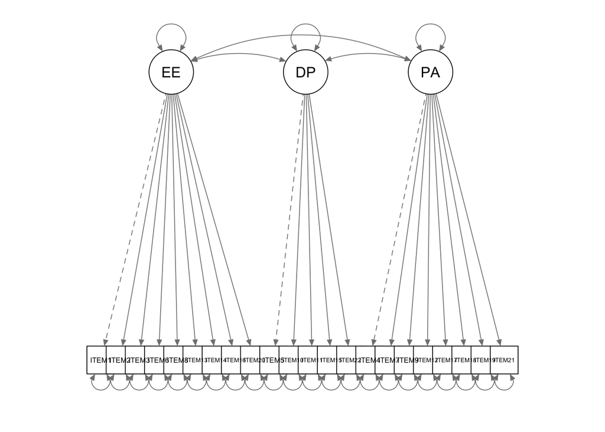

With this estimator the hypothesis that burnout has three factors is also not supported by the results (chi square statistic = 567.753, p = 0.000), which suggest that the fit of the data to the model is not adequate and null hypothesis should be rejected. Here the indices increase small amounts CFI (0.865), TLI (0.849) and RMSEA decreases small amount (0.076) but still these indices support against hypothesis.